# Tidymodels Exercise third

- Show All Code
- Hide All Code
- View Source

Author

Mateusz Zajda

Published

October 10, 2024

About

Exercise **third**

The task of this exercise is to train model for ozone prediction with logistic_regresion.

### 1.1 Required packages

**Hide/Show code**

```r
library(tidymodels)
library(skimr)
library(GGally)
library(openair)
library(DT)
library(dplyr)
library(ranger)
tidymodels_prefer()
```

### 1.2 Data preparation

**Hide/Show code**

```r
air <-
  mydata |>
  selectByDate(year = 2002)
air |> skim()
```

Data summary

| Name | air |
| --- | --- |
| Number of rows | 8760 |
| Number of columns | 10 |
| _______________________ |  |
| Column type frequency: |  |
| numeric | 9 |
| POSIXct | 1 |
| ________________________ |  |
| Group variables | None |

**Variable type: numeric**

| skim_variable | n_missing | complete_rate | mean | sd | p0 | p25 | p50 | p75 | p100 | hist |
| --- | --- | --- | --- | --- | --- | --- | --- | --- | --- | --- |
| ws | 13 | 1.00 | 5.05 | 2.74 | 0.5 | 3.09 | 4.60 | 6.57 | 19.60 | ▇▇▂▁▁ |
| wd | 27 | 1.00 | 193.18 | 93.20 | 0.0 | 130.00 | 200.00 | 250.00 | 360.00 | ▅▃▇▆▅ |
| nox | 135 | 0.98 | 156.62 | 100.01 | 7.0 | 75.00 | 137.00 | 220.00 | 695.00 | ▇▆▂▁▁ |
| no2 | 135 | 0.98 | 41.98 | 16.66 | 4.0 | 30.00 | 40.00 | 52.00 | 124.00 | ▃▇▃▁▁ |
| o3 | 263 | 0.97 | 7.38 | 8.04 | 0.0 | 2.00 | 4.00 | 10.00 | 52.00 | ▇▂▁▁▁ |
| pm10 | 163 | 0.98 | 34.12 | 17.39 | 1.0 | 22.00 | 32.00 | 43.00 | 511.00 | ▇▁▁▁▁ |
| so2 | 307 | 0.96 | 3.74 | 2.83 | 0.0 | 1.75 | 3.25 | 5.00 | 35.25 | ▇▁▁▁▁ |
| co | 216 | 0.98 | 1.24 | 0.78 | 0.0 | 0.60 | 1.05 | 1.70 | 4.58 | ▇▆▃▁▁ |
| pm25 | 618 | 0.93 | 21.43 | 9.94 | 0.0 | 14.00 | 20.00 | 27.00 | 112.00 | ▇▅▁▁▁ |

**Variable type: POSIXct**

| skim_variable | n_missing | complete_rate | min | max | median | n_unique |
| --- | --- | --- | --- | --- | --- | --- |
| date | 0 | 1 | 2002-01-01 | 2002-12-31 23:00:00 | 2002-07-02 11:30:00 | 8760 |

**Hide/Show code**

```r
air <-
  air |> na.omit()
```

### 1.3 Changing Ozone to categorical data

**Hide/Show code**

```r
air <-
  air |>
  mutate(ozone = cut(
  o3,
  breaks = c(-0.1, 10, 53),
  labels = c("Niskie", "Wysokie")
  ))

air |>
  select_if(is.numeric) |>
  cor(use = "complete.obs") |> as.data.frame() |> select(o3)
```

```
             o3
ws    0.3158281
wd    0.1020948
nox  -0.5457678
no2  -0.4483031
o3    1.0000000
pm10 -0.3070781
so2  -0.4102391
co   -0.4659199
pm25 -0.3629375
```

### 1.4 Splitting the data

**Hide/Show code**

```r
set.seed(222)
data_split <- initial_split(data=air, prop = 3/4, strata = ozone)
train_data <- training(data_split)
test_data <- testing(data_split)
```

### 1.5 Resampling V-fold CV, bootstrap

**Hide/Show code**

```r
set.seed(345)
vcv_folds <- vfold_cv(data=train_data, v=10)
bootstrap_folds <- bootstraps(data=train_data, times=5)
```

### 1.6 Creating recipe for ozone classification model

**Hide/Show code**

```r
ozone_recipe <-
  recipe(ozone ~ ., data = train_data) |>
  update_role(o3, wd, date, pm10, pm25, so2, co, no2, new_role = "ID") |>
  step_BoxCox(ws, nox, no2) |>  # daje ten sam efet co metoda Yeo-Johnson
  # step_normalize(ws, nox, no2) |> # nie pomaga
  step_date(date, features = c("month")) |>
  step_time(date, features = c("hour")) |>
  step_mutate(date_hour = as.factor(date_hour)) |>
  step_dummy(all_nominal_predictors()) |>
  step_zv()
```

### 1.7 Examine the recipe

**Hide/Show code**

```r
ozone_recipe |> summary()
```

```
# A tibble: 11 × 4
   variable type      role      source
   <chr>    <list>    <chr>     <chr>
 1 date     <chr [1]> ID        original
 2 ws       <chr [2]> predictor original
 3 wd       <chr [2]> ID        original
 4 nox      <chr [2]> predictor original
 5 no2      <chr [2]> ID        original
 6 o3       <chr [2]> ID        original
 7 pm10     <chr [2]> ID        original
 8 so2      <chr [2]> ID        original
 9 co       <chr [2]> ID        original
10 pm25     <chr [2]> ID        original
11 ozone    <chr [3]> outcome   original
```

**Hide/Show code**

```r
ozone_recipe |>
  prep() |>
  bake(new_data = train_data) |>
  head(10) |>
  DT::datatable()
```

|  | date | ws | wd | nox | no2 | o3 | pm10 | so2 | co | pm25 | ozone | date_month_Feb | date_month_Mar | date_month_Apr | date_month_May | date_month_Jun | date_month_Jul | date_month_Aug | date_month_Sep | date_month_Oct | date_month_Nov | date_month_Dec | date_hour_X1 | date_hour_X2 | date_hour_X3 | date_hour_X4 | date_hour_X5 | date_hour_X6 | date_hour_X7 | … |
| --- | --- | --- | --- | --- | --- | --- | --- | --- | --- | --- | --- | --- | --- | --- | --- | --- | --- | --- | --- | --- | --- | --- | --- | --- | --- | --- | --- | --- | --- | --- |
| 1 | 2002-01-01T00:00:00Z | 1.251724691832815 | 0 | 21.82430049884195 | 13.03893228168225 | 2 | 62 | 9.25 | 2.925 | 53 | Niskie | 0 | 0 | 0 | 0 | 0 | 0 | 0 | 0 | 0 | 0 | 0 | 0 | 0 | 0 | 0 | 0 | 0 | 0 | … |
| 2 | 2002-01-01T01:00:00Z | 0.4831392007148267 | 220 | 21.1354444382171 | 15.00812882534997 | 3 | 70 | 9.5 | 2.966667 | 57 | Niskie | 0 | 0 | 0 | 0 | 0 | 0 | 0 | 0 | 0 | 0 | 0 | 1 | 0 | 0 | 0 | 0 | 0 | 0 | … |
| 3 | 2002-01-01T05:00:00Z | -0.1681070316478493 | 140 | 18.76989230116437 | 11.04931436893475 | 2 | 64 | 7 | 2.05 | 51 | Niskie | 0 | 0 | 0 | 0 | 0 | 0 | 0 | 0 | 0 | 0 | 0 | 0 | 0 | 0 | 0 | 1 | 0 | 0 | … |
| 4 | 2002-01-01T06:00:00Z | -0.03406556414780428 | 330 | 19.76421161954749 | 12.26984991777157 | 2 | 64 | 9.25 | 2.25 | 52 | Niskie | 0 | 0 | 0 | 0 | 0 | 0 | 0 | 0 | 0 | 0 | 0 | 0 | 0 | 0 | 0 | 0 | 1 | 0 | … |
| 5 | 2002-01-01T07:00:00Z | 0.6720062719556742 | 340 | 19.56658932714262 | 13.59565938210666 | 2 | 60 | 8.5 | 2.075 | 49 | Niskie | 0 | 0 | 0 | 0 | 0 | 0 | 0 | 0 | 0 | 0 | 0 | 0 | 0 | 0 | 0 | 0 | 0 | 1 | … |
| 6 | 2002-01-01T08:00:00Z | 0.5890353268618026 | 120 | 18.90191859940841 | 13.03893228168225 | 1 | 56 | 7.75 | 1.725 | 46 | Niskie | 0 | 0 | 0 | 0 | 0 | 0 | 0 | 0 | 0 | 0 | 0 | 0 | 0 | 0 | 0 | 0 | 0 | 0 | … |
| 7 | 2002-01-01T10:00:00Z | -0.1103322398562163 | 320 | 19.83753520496151 | 13.95812918759122 | 2 | 56 | 10 | 1.75 | 47 | Niskie | 0 | 0 | 0 | 0 | 0 | 0 | 0 | 0 | 0 | 0 | 0 | 0 | 0 | 0 | 0 | 0 | 0 | 0 | … |
| 8 | 2002-01-01T12:00:00Z | -0.1103322398562163 | 350 | 18.36496200684343 | 13.03893228168225 | 2 | 72 | 9.5 | 1.725 | 37 | Niskie | 0 | 0 | 0 | 0 | 0 | 0 | 0 | 0 | 0 | 0 | 0 | 0 | 0 | 0 | 0 | 0 | 0 | 0 | … |
| 9 | 2002-01-01T13:00:00Z | -0.1205647366668165 | 20 | 18.28231117911629 | 13.77772729423993 | 2 | 118 | 8.25 | 1.775 | 50 | Niskie | 0 | 0 | 0 | 0 | 0 | 0 | 0 | 0 | 0 | 0 | 0 | 0 | 0 | 0 | 0 | 0 | 0 | 0 | … |
| 10 | 2002-01-01T14:00:00Z | 1.334925406435523 | 120 | 18.50145638820764 | 14.66401770573099 | 2 | 104 | 7.5 | 2 | 45 | Niskie | 0 | 0 | 0 | 0 | 0 | 0 | 0 | 0 | 0 | 0 | 0 | 0 | 0 | 0 | 0 | 0 | 0 | 0 | … |

### 1.8 Defining model

**Hide/Show code**

```r
lr_mod <-
  logistic_reg() |>
  set_engine("glm")

rf_mod <-
  rand_forest() |>
  set_engine("ranger") |>
  set_mode("classification")
```

### 1.9 Creating workflow

**Hide/Show code**

```r
ozone_lr_work <-
  workflow() |>
  add_model(lr_mod) |>
  add_recipe(ozone_recipe)

ozone_rf_work <-
  workflow() |>
  add_model(rf_mod) |>
  add_recipe(ozone_recipe)
```

### 1.10 Tune

**Hide/Show code**

```r
lr_fit_vcv <-
  ozone_lr_work |>
  fit_resamples(vcv_folds)

lr_fit_bootstrap <-
  ozone_lr_work |>
  fit_resamples(bootstrap_folds)

rf_fit_vcv <-
  ozone_rf_work |>
  fit_resamples(vcv_folds)

rf_fit_bootstrap <-
  ozone_rf_work |>
  fit_resamples(bootstrap_folds)
```

### 1.11 Model without resampling

**Hide/Show code**

```r
ozone_work <-
  workflow() |>
  add_model(lr_mod) |>
  add_recipe(ozone_recipe)

ozone_fit <-
  ozone_work |>
  fit(data=train_data)
```

### 1.12 Prediction for model without resampling

**Hide/Show code**

```r
ozone_fit |>
  predict(test_data, type="prob")
```

```
# A tibble: 1,890 × 2
   .pred_Niskie .pred_Wysokie
          <dbl>         <dbl>
 1        1.00    0.000000952
 2        1.00    0.00000417
 3        1.00    0.0000653
 4        1.00    0.000481
 5        0.999   0.000845
 6        1.00    0.000381
 7        0.991   0.00944
 8        1.00    0.000174
 9        0.998   0.00154
10        0.984   0.0161
# ℹ 1,880 more rows
```

### 1.13 Concat fit with test data

**Hide/Show code**

```r
pred_test <-
  augment(ozone_fit, test_data) |>
  select(-ws,
         -wd,
         -o3,
         -nox,
         -no2,
         -pm10,
         -pm25,
         -so2,
         -co,
         -date)
pred_test
```

```
# A tibble: 1,890 × 4
   .pred_class .pred_Niskie .pred_Wysokie ozone
   <fct>              <dbl>         <dbl> <fct>
 1 Niskie             1.00    0.000000952 Niskie
 2 Niskie             1.00    0.00000417  Niskie
 3 Niskie             1.00    0.0000653   Niskie
 4 Niskie             1.00    0.000481    Niskie
 5 Niskie             0.999   0.000845    Niskie
 6 Niskie             1.00    0.000381    Niskie
 7 Niskie             0.991   0.00944     Niskie
 8 Niskie             1.00    0.000174    Niskie
 9 Niskie             0.998   0.00154     Niskie
10 Niskie             0.984   0.0161      Niskie
# ℹ 1,880 more rows
```

### 1.14 Display ROC curve

**Hide/Show code**

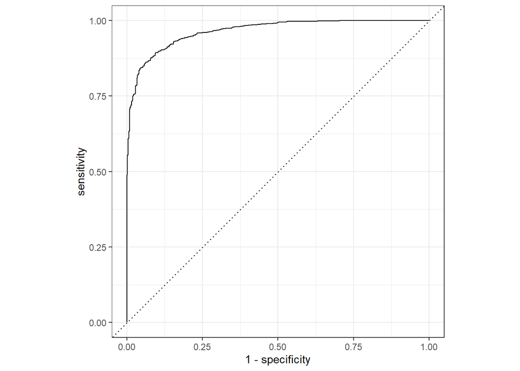

```r
pred_test  |>
  roc_curve(truth = ozone, .pred_Niskie) |>
  autoplot()
```

### 1.15 Counting ‘Niskie’ and ‘Wysokie’ values in test set and prediction set

**Hide/Show code**

```r
pred_test |> count(ozone)
```

```
# A tibble: 2 × 2
  ozone       n
  <fct>   <int>
1 Niskie   1441
2 Wysokie   449
```

**Hide/Show code**

```r
pred_test |> count(.pred_class)
```

```
# A tibble: 2 × 2
  .pred_class     n
  <fct>       <int>
1 Niskie       1486
2 Wysokie       404
```

### 1.16 Metrics

**Hide/Show code**

```r
bind_rows(
  pred_test |>
    roc_auc(truth = ozone, .pred_Niskie),

  pred_test |>
    accuracy(truth = ozone, .pred_class)
) |>
  knitr::kable(digits = 3)
```

| .metric | .estimator | .estimate |
| --- | --- | --- |
| roc_auc | binary | 0.965 |
| accuracy | binary | 0.913 |

### 1.17 Metrics for models with resampling

**Hide/Show code**

```r
lr_fit_vcv|>
  collect_metrics() |>
  knitr::kable(digits = 3)
```

| .metric | .estimator | mean | n | std_err | .config |
| --- | --- | --- | --- | --- | --- |
| accuracy | binary | 0.906 | 10 | 0.003 | Preprocessor1_Model1 |
| brier_class | binary | 0.068 | 10 | 0.002 | Preprocessor1_Model1 |
| roc_auc | binary | 0.958 | 10 | 0.002 | Preprocessor1_Model1 |

**Hide/Show code**

```r
lr_fit_bootstrap|>
  collect_metrics() |>
  knitr::kable(digits = 3)
```

| .metric | .estimator | mean | n | std_err | .config |
| --- | --- | --- | --- | --- | --- |
| accuracy | binary | 0.903 | 5 | 0.001 | Preprocessor1_Model1 |
| brier_class | binary | 0.068 | 5 | 0.001 | Preprocessor1_Model1 |
| roc_auc | binary | 0.958 | 5 | 0.001 | Preprocessor1_Model1 |

**Hide/Show code**

```r
rf_fit_vcv|>
  collect_metrics() |>
  knitr::kable(digits = 3)
```

| .metric | .estimator | mean | n | std_err | .config |
| --- | --- | --- | --- | --- | --- |
| accuracy | binary | 0.903 | 10 | 0.004 | Preprocessor1_Model1 |
| brier_class | binary | 0.073 | 10 | 0.002 | Preprocessor1_Model1 |
| roc_auc | binary | 0.955 | 10 | 0.002 | Preprocessor1_Model1 |

**Hide/Show code**

```r
rf_fit_bootstrap|>
  collect_metrics() |>
  knitr::kable(digits = 3)
```

| .metric | .estimator | mean | n | std_err | .config |
| --- | --- | --- | --- | --- | --- |
| accuracy | binary | 0.896 | 5 | 0.003 | Preprocessor1_Model1 |
| brier_class | binary | 0.074 | 5 | 0.001 | Preprocessor1_Model1 |
| roc_auc | binary | 0.952 | 5 | 0.002 | Preprocessor1_Model1 |

## 2 Conslusions:

- The resampling models accuracy and roc_auc are lower then withuot using the resampling methods but are more realistic and stable;
- Accuracy of the models with using the resampling methods equals around 90%, all of the models are almost exacly the same good for this prediction case;
- In this case best resampling model was the one that included logistic_regression and V-fold Cross-Validation and the worst was the one with RandomForest model and bootstrap resampling method;